# What is Diamonds Prices Dataset?

# About the currency for the price column: it is Price ($)

And About the columns x,y, and z they are diamond measurements as (( x: length in mm, y: width in mm,z: depth in mm ))

```python
# There are 10 columns
#carat:Weight of the diamond
#cut:Quality of the cut (Fair, Good, Very Good, Premium, Ideal)
#color:Diamond colour, from J (worst) to D (best)
#clarity:How clear the diamond is (I1 (worst), SI2, SI1, VS2, VS1, VVS2, VVS1, IF (best))
#x:Length in mm
#y:Width in mm
#z:Depth in mm
#depth:Total depth percentage = z / mean(x, y) = 2 * z / (x + y) (43--79)
#table:Width of top of diamond relative to widest point (43--95)
#price:Price in US dollars (326--18,823)
```

# importing the libraries

```python
import numpy as np
import pandas as pd
import seaborn as sns
import matplotlib.pyplot as plt
```

```python
df = pd.read_csv("D:/Datasets/Diamonds Prices2022.csv")
df.head()
```

|  | Unnamed: 0 | carat | cut | color | clarity | depth | table | price | x | y | z |
| --- | --- | --- | --- | --- | --- | --- | --- | --- | --- | --- | --- |
| 0 | 1 | 0.23 | Ideal | E | SI2 | 61.5 | 55.0 | 326 | 3.95 | 3.98 | 2.43 |
| 1 | 2 | 0.21 | Premium | E | SI1 | 59.8 | 61.0 | 326 | 3.89 | 3.84 | 2.31 |
| 2 | 3 | 0.23 | Good | E | VS1 | 56.9 | 65.0 | 327 | 4.05 | 4.07 | 2.31 |
| 3 | 4 | 0.29 | Premium | I | VS2 | 62.4 | 58.0 | 334 | 4.20 | 4.23 | 2.63 |
| 4 | 5 | 0.31 | Good | J | SI2 | 63.3 | 58.0 | 335 | 4.34 | 4.35 | 2.75 |

# Data Preprocessing

```python
df.shape
```

```
(53943, 11)
```

```python
#checking for null values
df.info()
```

```
<class 'pandas.core.frame.DataFrame'>
RangeIndex: 53943 entries, 0 to 53942
Data columns (total 11 columns):
 #   Column      Non-Null Count  Dtype
---  ------      --------------  -----
 0   Unnamed: 0  53943 non-null  int64
 1   carat       53943 non-null  float64
 2   cut         53943 non-null  object
 3   color       53943 non-null  object
 4   clarity     53943 non-null  object
 5   depth       53943 non-null  float64
 6   table       53943 non-null  float64
 7   price       53943 non-null  int64
 8   x           53943 non-null  float64
 9   y           53943 non-null  float64
 10  z           53943 non-null  float64
dtypes: float64(6), int64(2), object(3)
memory usage: 4.5+ MB
```

```python
#checking discrptive Values
df.describe()
```

|  | Unnamed: 0 | carat | depth | table | price | x | y | z |
| --- | --- | --- | --- | --- | --- | --- | --- | --- |
| count | 53943.000000 | 53943.000000 | 53943.000000 | 53943.000000 | 53943.000000 | 53943.000000 | 53943.000000 | 53943.000000 |
| mean | 26972.000000 | 0.797935 | 61.749322 | 57.457251 | 3932.734294 | 5.731158 | 5.734526 | 3.538730 |
| std | 15572.147122 | 0.473999 | 1.432626 | 2.234549 | 3989.338447 | 1.121730 | 1.142103 | 0.705679 |
| min | 1.000000 | 0.200000 | 43.000000 | 43.000000 | 326.000000 | 0.000000 | 0.000000 | 0.000000 |
| 25% | 13486.500000 | 0.400000 | 61.000000 | 56.000000 | 950.000000 | 4.710000 | 4.720000 | 2.910000 |
| 50% | 26972.000000 | 0.700000 | 61.800000 | 57.000000 | 2401.000000 | 5.700000 | 5.710000 | 3.530000 |
| 75% | 40457.500000 | 1.040000 | 62.500000 | 59.000000 | 5324.000000 | 6.540000 | 6.540000 | 4.040000 |
| max | 53943.000000 | 5.010000 | 79.000000 | 95.000000 | 18823.000000 | 10.740000 | 58.900000 | 31.800000 |

```python
#values count for categorical values
df["cut"].value_counts()
```

```
Ideal        21551
Premium      13793
Very Good    12083
Good          4906
Fair          1610
Name: cut, dtype: int64
```

```python
df["color"].value_counts()
```

```
G    11292
E     9799
F     9543
H     8304
D     6775
I     5422
J     2808
Name: color, dtype: int64
```

```python
df["clarity"].value_counts()
```

```
SI1     13067
VS2     12259
SI2      9194
VS1      8171
VVS2     5066
VVS1     3655
IF       1790
I1        741
Name: clarity, dtype: int64
```

```python
df.head(10)
```

|  | Unnamed: 0 | carat | cut | color | clarity | depth | table | price | x | y | z |
| --- | --- | --- | --- | --- | --- | --- | --- | --- | --- | --- | --- |
| 0 | 1 | 0.23 | Ideal | E | SI2 | 61.5 | 55.0 | 326 | 3.95 | 3.98 | 2.43 |
| 1 | 2 | 0.21 | Premium | E | SI1 | 59.8 | 61.0 | 326 | 3.89 | 3.84 | 2.31 |
| 2 | 3 | 0.23 | Good | E | VS1 | 56.9 | 65.0 | 327 | 4.05 | 4.07 | 2.31 |
| 3 | 4 | 0.29 | Premium | I | VS2 | 62.4 | 58.0 | 334 | 4.20 | 4.23 | 2.63 |
| 4 | 5 | 0.31 | Good | J | SI2 | 63.3 | 58.0 | 335 | 4.34 | 4.35 | 2.75 |
| 5 | 6 | 0.24 | Very Good | J | VVS2 | 62.8 | 57.0 | 336 | 3.94 | 3.96 | 2.48 |
| 6 | 7 | 0.24 | Very Good | I | VVS1 | 62.3 | 57.0 | 336 | 3.95 | 3.98 | 2.47 |
| 7 | 8 | 0.26 | Very Good | H | SI1 | 61.9 | 55.0 | 337 | 4.07 | 4.11 | 2.53 |
| 8 | 9 | 0.22 | Fair | E | VS2 | 65.1 | 61.0 | 337 | 3.87 | 3.78 | 2.49 |
| 9 | 10 | 0.23 | Very Good | H | VS1 | 59.4 | 61.0 | 338 | 4.00 | 4.05 | 2.39 |

# Exploratory Data Analysis

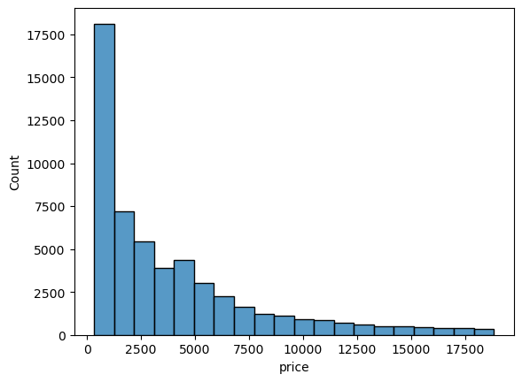

```python
sns.histplot(df['price'],bins=20)
```

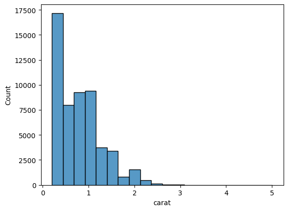

```python
sns.histplot(df['carat'],bins=20)
```

# Most of the diamonds are less than 1 carat in weight

[figure not shown]

```python
plt.figure(figsize=(5,5))
plt.pie(df["cut"].value_counts(),labels=["ideal","Fair","Good","Very Good","Premium"])
plt.title("Cut")
plt.show()
```

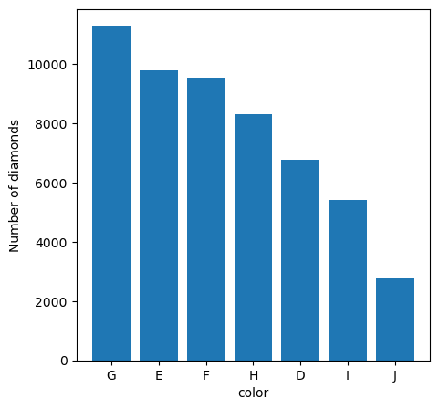

```python
plt.figure(figsize=(5,5))
plt.bar(df["color"].value_counts().index,df["color"].value_counts())
plt.ylabel("Number of diamonds")
plt.xlabel("color")
plt.show()
```

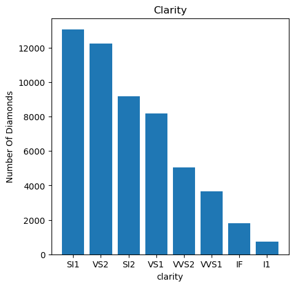

```python
plt.figure(figsize=(5,5))
plt.bar(df["clarity"].value_counts().index,df["clarity"].value_counts())
plt.title("Clarity")
plt.ylabel("Number Of Diamonds")
plt.xlabel("clarity")
plt.show()
```

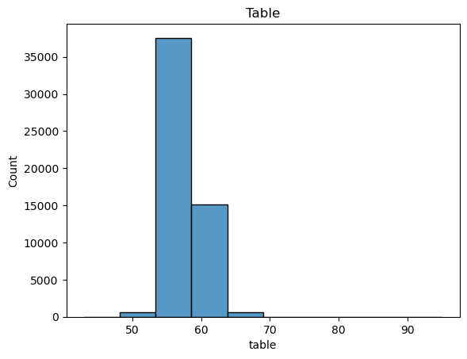

```python
sns.histplot(df["table"],bins=10)
plt.title("Table")
plt.show()
```

# Compairing Diamond's Features With Price

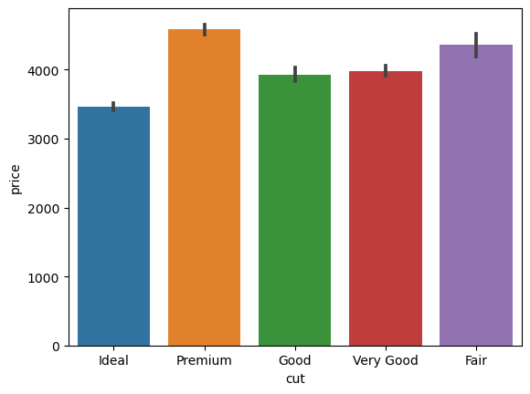

```python
sns.barplot(x="cut",y="price",data=df)
```

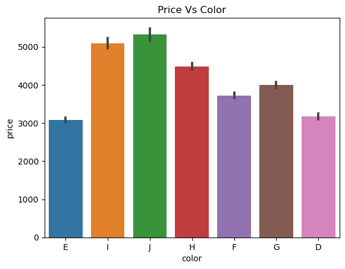

```python
sns.barplot(x="color",y="price",data=df)
plt.title("Price Vs Color")
plt.show()
```

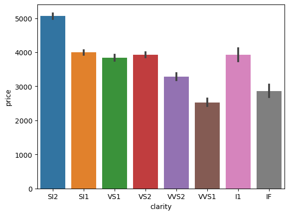

```python
sns.barplot(x="clarity", y="price",data=df)
```

# j color and I1 color are the worst features of the diamond,however when the data is plotted onthe bar graph.it seen the price of diamonds with J and I1 clarity is higher.

# Than the price of diamonds of D color and IF clarity,which is opposite to each other what i expected

# Data Preprocessing2

```python
df["cut"] = df["cut"].map({"Ideal":5,"Premium":4,"Very Good":3,"Good":2,"Fair":1})
df["color"] = df["color"].map({"D":7,"E":6,"F":5,"G":4,"H":3,"I":2,"J":1})
df["clarity"] = df["clarity"].map({"IF":8,"VVS1":7,"VVS2":6,"VS1":5,"VS2":4,"SI1":3,"SI2":2,"I1":1})
```

# Coorealation

```python
#coorealtion matrix
df.corr()
```

|  | Unnamed: 0 | carat | cut | color | clarity | depth | table | price | x | y | z |
| --- | --- | --- | --- | --- | --- | --- | --- | --- | --- | --- | --- |
| Unnamed: 0 | 1.000000 | -0.377970 | 0.096462 | 0.095160 | 0.208538 | -0.034896 | -0.100764 | -0.306875 | -0.405405 | -0.395809 | -0.399185 |
| carat | -0.377970 | 1.000000 | -0.134964 | -0.291439 | -0.352833 | 0.028234 | 0.181602 | 0.921591 | 0.975093 | 0.951721 | 0.953387 |
| cut | 0.096462 | -0.134964 | 1.000000 | 0.020506 | 0.189171 | -0.218037 | -0.433387 | -0.053487 | -0.125564 | -0.121461 | -0.149320 |
| color | 0.095160 | -0.291439 | 0.020506 | 1.000000 | -0.025646 | -0.047316 | -0.026457 | -0.172520 | -0.270281 | -0.263579 | -0.268226 |
| clarity | 0.208538 | -0.352833 | 0.189171 | -0.025646 | 1.000000 | -0.067355 | -0.160328 | -0.146791 | -0.371996 | -0.358417 | -0.366946 |
| depth | -0.034896 | 0.028234 | -0.218037 | -0.047316 | -0.067355 | 1.000000 | -0.295798 | -0.010630 | -0.025289 | -0.029340 | 0.094927 |
| table | -0.100764 | 0.181602 | -0.433387 | -0.026457 | -0.160328 | -0.295798 | 1.000000 | 0.127118 | 0.195333 | 0.183750 | 0.150915 |
| price | -0.306875 | 0.921591 | -0.053487 | -0.172520 | -0.146791 | -0.010630 | 0.127118 | 1.000000 | 0.884433 | 0.865419 | 0.861249 |
| x | -0.405405 | 0.975093 | -0.125564 | -0.270281 | -0.371996 | -0.025289 | 0.195333 | 0.884433 | 1.000000 | 0.974701 | 0.970771 |
| y | -0.395809 | 0.951721 | -0.121461 | -0.263579 | -0.358417 | -0.029340 | 0.183750 | 0.865419 | 0.974701 | 1.000000 | 0.952005 |
| z | -0.399185 | 0.953387 | -0.149320 | -0.268226 | -0.366946 | 0.094927 | 0.150915 | 0.861249 | 0.970771 | 0.952005 | 1.000000 |

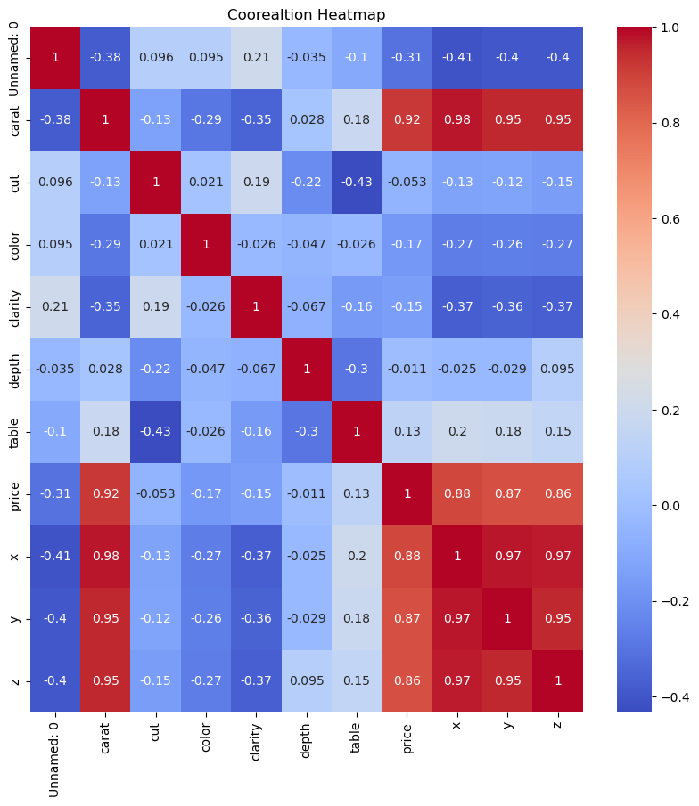

```python
#plotting the coorealtion heatmap
plt.figure(figsize=(10,10))
sns.heatmap(df.corr(),annot=True,cmap="coolwarm")
plt.title("Coorealtion Heatmap")
plt.show()
```

# Plotting the relationship between price and carat

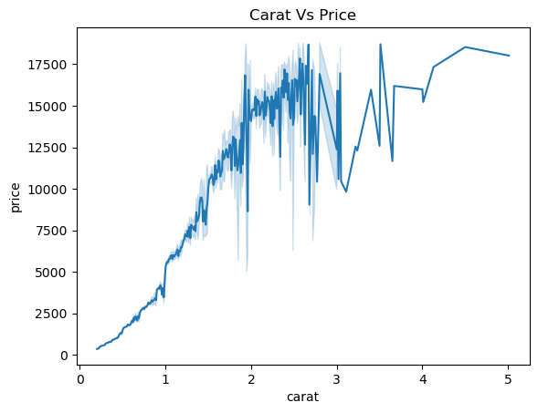

```python
sns.lineplot(x="carat",y="price",data=df)
plt.title("Carat Vs Price")
plt.show()
```

# From the lineplot it is quite to clear the price of diamonds is increasing with the increase of the carat of the diamonds.

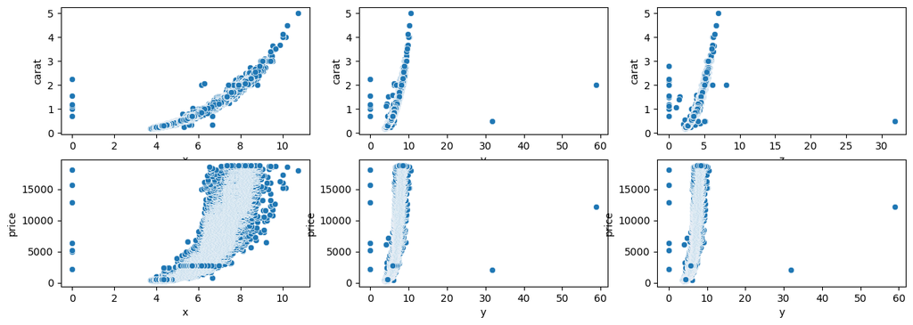

```python
fig,ax = plt.subplots(2,3,figsize=(15,5))
sns.scatterplot(x="x",y="carat",data=df,ax=ax[0,0])
sns.scatterplot(x="y",y="carat",data=df,ax=ax[0,1])
sns.scatterplot(x="z",y="carat",data=df,ax=ax[0,2])
sns.scatterplot(x="x",y="price",data=df,ax=ax[1,0])
sns.scatterplot(x="y",y="price",data=df,ax=ax[1,1])
sns.scatterplot(x="y",y="price",data=df,ax=ax[1,2])
plt.show()
```

```python
#Majority of the diamonds have x values between 4 and 8 ,y values between 4 and 10,and z values between 2 and 6,Diamonds with other Diamensions are very rare.
```

# Train And testing

```python
from sklearn.model_selection import train_test_split
x_test,x_train,y_test,y_train = train_test_split(df.drop('price',axis=1),df['price'],test_size=0.2,random_state=42)
```

# Decision Tree Regressor

```python
from sklearn.tree import DecisionTreeRegressor
dt = DecisionTreeRegressor()
dt
```

```
DecisionTreeRegressor()
```

```python
#training the model
dt.fit(x_train,y_train)
#train accuracy
dt.score(x_train,y_train)
```

```
1.0
```

```python
#predicting the test set
dt_pred = dt.predict(x_test)
```

# Random Forest Regressor

```python
from sklearn.ensemble import RandomForestRegressor
rf = RandomForestRegressor()
rf
```

```
RandomForestRegressor()
```

```python
#training the model
rf.fit(x_train,y_train)
#train accuracy
rf.score(x_train,y_train)
```

```
0.9998750994313683
```

```python
#predicting the test set
rf_pred = rf.predict(x_test)
```

# Model Evalution

```python
from sklearn.metrics import mean_squared_error,mean_absolute_error
```

# Decision Tree Regressor

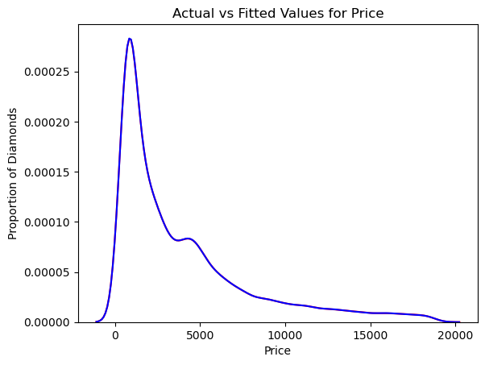

```python
#distribution plot for actual and predicted values
ax = sns.distplot(y_test,hist=False,color='r',label='Actual Value')
sns.distplot(dt_pred,hist=False,color='b',label='Fitted Values',ax=ax)
plt.title('Actual vs Fitted Values for Price')
plt.xlabel('Price')
plt.ylabel('Proportion of Diamonds')
plt.show()
```

```python
print('Decision Tree Regressor RMSE:',np.sqrt(mean_squared_error(y_test,dt_pred)))
print('Decision Tree Regressor Accuracy:',dt.score(x_test,y_test))
print('Decision Tree Regressor MAE:',mean_absolute_error(y_test,dt_pred))
```

```
Decision Tree Regressor RMSE: 144.69448278839047
Decision Tree Regressor Accuracy: 0.9986905599531942
Decision Tree Regressor MAE: 10.1044630856931
```

# Random Forest Regressor

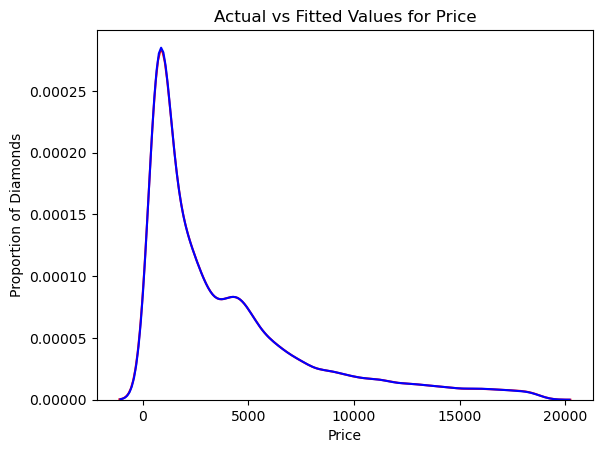

```python
#distribution plot for actual and predicted values
ax = sns.distplot(y_test,hist=False,color='r',label='Actual Value')
sns.distplot(rf_pred,hist=False,color='b',label='Fitted Values',ax=ax)
plt.title('Actual vs Fitted Values for Price')
plt.xlabel('Price')
plt.ylabel('Proportion of Diamonds')
plt.show()
```

```python
print('Random Forest Regressor RMSE:',np.sqrt(mean_squared_error(y_test,rf_pred)))
print('Random Forest Regressor Accuracy:',rf.score(x_test,y_test))
print('Random Forest Regressor MAE:',mean_absolute_error(y_test,rf_pred))
```

```
Random Forest Regressor RMSE: 84.844681294585
Random Forest Regressor Accuracy: 0.9995497736378737
Random Forest Regressor MAE: 8.241404968253235
```

# Conclusion

Both the models have almost same accuracy. However, the Random Forest Regressor model is slightly better than the Decision Tree Regressor model.

There is something interesting about the data. The price of the diamonds with J color and I1 clarity is higher than the price of the diamonds with D color and IF clarity which couldn't be explained by the models. This could be because of the other factors that affect the price of the diamond.